# Project 02

Tobechi Dimkpa

February 4th 2025

## Ramen Ratings

This data was collected from www.theramenrater.com. It provides information on different reviews of ramen products, and has variables: Review #, Brand, Variety, Style, Country, Stars, and Top Ten.

#### (a)

Read in ramen reviews dataset Renamed variables, converted Stars to numeric, and removed invalid entries

```r
ramen2 <- read_csv("data/ramen-ratings.csv")

ramen <- ramen2 %>%
  rename(review_number = `Review #`, top_ten = `Top Ten` ) %>%
  mutate(Stars = as.numeric(Stars)) %>%
  filter(!is.na(Stars))
```

#### (c)

Filtering just for the the ‘Nissin’ ramen brand, calculate the average rating for each country of this brand.

```r
nissinramen <- ramen %>%
  filter(Brand == "Nissin") %>%
  group_by(Country) %>%
  summarize(avgrating = mean(Stars))

#Brazil has the highest rating while the Philippines has the lowest rating
```

#### (d)

Created a new variable called “popular” which returns a 1 for entries that have a rating above or equal to 4.5 stars, and 0 for those that don’t.

```r
updatedramen <- ramen %>%
  mutate(popular= if_else(Stars >= "4.5", "1","0"))
```

#### (e)

Calculated the average stars for popular and not popular ramen.

```r
averagestars <- updatedramen %>%
  group_by(popular) %>%
  summarize(mean_score = mean(Stars))
print (averagestars)
```

```
## # A tibble: 2 × 2
##   popular mean_score
##   <chr>        <dbl>
## 1 0             3.30
## 2 1             4.86
```

```r
# It would be concerning because the rating 4.5 or above means the ramen is classified as popular. An average below 4.5 suggests an error in the data
```

## NYC Airbnb Analysis

#### (a)

Data preparation. Note, the neighborhood_group variable refers to borough.

```r
airbnb <- read_csv("data/AB_NYC_2019.csv")%>%
 select( host_name, neighbourhood_group, room_type, price, minimum_nights, number_of_reviews)
```

#### (b)

Created a new variable called minimum_price, which combines the minimum nights and price (per night) to give the minimum amount someone could pay to stay at the Airbnb.

```r
newairbnb <- mutate(airbnb, minimum_price = minimum_nights*price)
```

#### (c)

Calculated the mean and median minimum_price using ‘summarize’.

```r
summarize(newairbnb, mean(minimum_price), median(minimum_price))
```

```
## # A tibble: 1 × 2
##   `mean(minimum_price)` `median(minimum_price)`
##                   <dbl>                   <dbl>
## 1                 1284.                     300
```

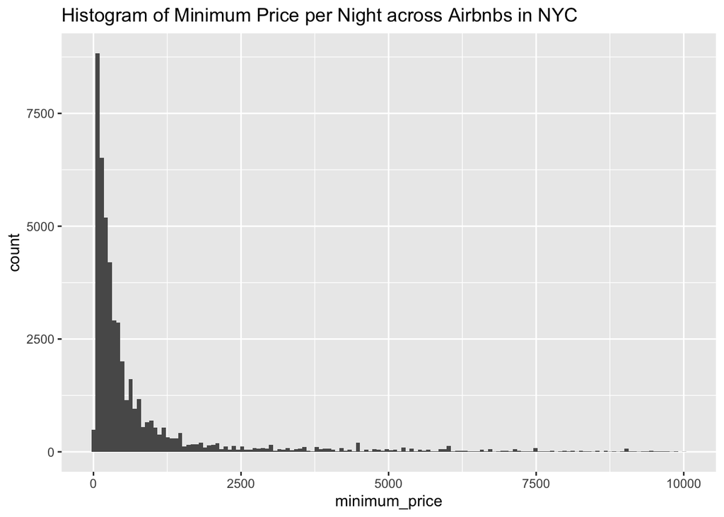

```r
#I expect the data to be right skewed as the mean is greater than the median

airbnbfiltered <- newairbnb %>%
  filter(minimum_price < 10000)

ggplot(data = airbnbfiltered) +
  geom_histogram(aes(x=minimum_price), binwidth = 70)+
  labs(title = "Histogram of Minimum Price per Night across Airbnbs in NYC")
```

```r
#The histogram is right skewed
```

#### (d)

Borough representation: Are all of the New York City boroughs represented in the data?

```r
borough <- newairbnb %>%
  group_by(neighbourhood_group) %>%
  summarize(boroughtotal = n())

#Yes, all boroughs are represented but Manhattan and Brooklyn account for most of the airbnbs in the city
```

#### (e)

Price Distribution by Borough: Plot a boxplot of price across boroughs, showing only properties less than 1,000 a night.

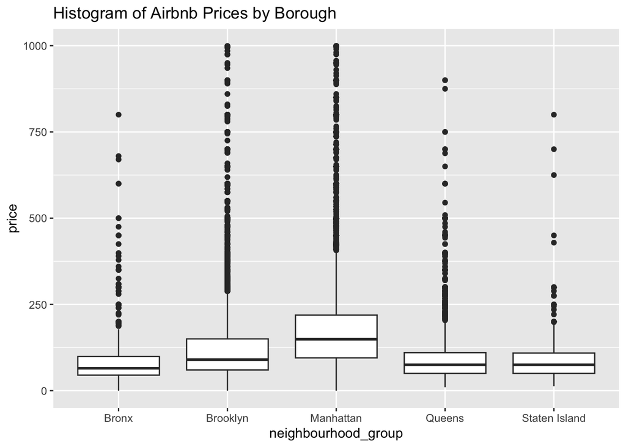

```r
newairbnb %>%
  filter(price < 1000) %>%
  group_by(neighbourhood_group) %>%
  ggplot () +
  geom_boxplot(aes(x=neighbourhood_group, y=price)) +
  labs(title = "Histogram of Airbnb Prices by Borough")
```

```r
#Manhattan seems to have the highest median price and the Bronx has the lowest using the graph

#Confirmation
newairbnb %>%
  filter(price < 1000) %>%
  group_by(neighbourhood_group) %>%
  summarize(median(price))
```

```
## # A tibble: 5 × 2
##   neighbourhood_group `median(price)`
##   <chr>                         <dbl>
## 1 Bronx                            65
## 2 Brooklyn                         90
## 3 Manhattan                       149
## 4 Queens                           75
## 5 Staten Island                    75
```

```r
#The median price of airbnbs in the different boroughs in nyc is $65 for the Bronx, $90 for Brooklyn, $149 for Manhattan, $75 for Queens and $75 for Staten Island.
```

#### (f)

Most common Host name

```r
newairbnb%>%
  group_by(host_name) %>%
  summarise(n = n()) %>%
  arrange((-n))
```

```
## # A tibble: 11,453 × 2
##    host_name        n
##    <chr>        <int>
##  1 Michael        417
##  2 David          403
##  3 Sonder (NYC)   327
##  4 John           294
##  5 Alex           279
##  6 Blueground     232
##  7 Sarah          227
##  8 Daniel         226
##  9 Jessica        205
## 10 Maria          204
## # ℹ 11,443 more rows
```

```r
#Michael is the most common host name
```

## Depression drug analysis

#### (a)

Dataset: STUDYDAT12014.csv Variables: treatment (trx), placebo, dose, age, HAM-D/HAM-A (baseline & outcome)

```r
depression_drug <- read_csv("data/STUDYDAT12014.csv")

#There are 200 observations and 8 variables
```

#### (b)

Filtering Midlife Participants (30–39 years old)

```r
midlife <- depression_drug %>%
  filter(age >= 30 & age < 40)
```

#### (c)

Relabeling treatment groups: The treatment groups are currently labeled `pbo` and `trx`, but the researchers would like to have them labeled `Placebo` and `Drug 13XA`.

```r
 midlife <- midlife %>%
  mutate(trx = if_else(trx == "pbo", "Placebo", "Drug 13XA"))
```

#### (d)

Calculating score changes: changes between baseline and outcome measurements for HAM-A and HAM-D.

```r
midlife <- midlife %>%
  mutate(hamd_diff = outcome_hamd - baseline_hamd, hama_diff = outcome_hama - baseline_hama)
```

#### (e)

T-tests (unequal variance): Is there is a difference in (1) mean HAM-A changes between treatment groups and (2) mean HAM-D changes between treatment groups.

```r
drug_res <- t.test(hamd_diff~trx, data=midlife)

tstat <- round(drug_res$statistic, 3)

df <- drug_res$parameter # degrees of freedom

p <- drug_res$p.value %>% round(4)


drug_res2 <- t.test(hama_diff~trx, data=midlife)

tstat2 <- round(drug_res2$statistic, 3)

df2 <- drug_res2$parameter # degrees of freedom

p2 <- drug_res2$p.value %>% round(4)
```

HAM-A T-test: As the p-value is greater than 0.05, we fail to reject the null hypothesis; the data does not support that there is a significant difference in mean HAM-A changes between treatment groups. (t = -1.001; df = 38.9376515`; p = 0.3229)

HAM-D T-test: As the p-value is greater than 0.05, we fail to reject the null hypothesis; the data does not support that there is a significant difference in mean HAM-D changes between treatment groups. (t = 0.803; df = 45.1303189; p = 0.4265)

## Cafe Sales Analysis

#### (a)

Profitability and Summary Stats: dataset from a student-run cafe `cafedata.xls`. This dataset contains data from a cafe, called Executive Express, run by undergraduate business students at a Midwestern public university. It was collected over a ten-week period from January to April 2010.

```r
#Import data, drop missing variables and create profitable variable

cafedata <- read_excel("data/cafedata.xls", sheet = 2) %>%
  drop_na() %>%
  mutate(profitable_days = if_else(Sales >= 160, "profitable", "unprofitable"))

#Create summary dataframe to find how many profitable/unprofitable days
cafe_summary <- cafedata %>%
 count(profitable_days)
profitable_count <- cafe_summary %>% filter(profitable_days == "profitable") %>% pull(n)
unprofitable_count <- cafe_summary %>% filter(profitable_days == "unprofitable") %>% pull(n)

#Summarize Wraps Sold
wraps_summary <- cafedata %>%
  group_by(profitable_days) %>%
  summarize(mean_wraps = mean(`Wraps Sold`), sd_wraps = sd(`Wraps Sold`))

wraps_profitable <- wraps_summary %>% filter(profitable_days == "profitable") %>% pull(mean_wraps)
sd_profitable <- wraps_summary %>% filter(profitable_days == "profitable") %>% pull(sd_wraps)

wraps_unprofitable <- wraps_summary %>% filter(profitable_days == "unprofitable") %>% pull(mean_wraps)
sd_unprofitable <- wraps_summary %>% filter(profitable_days == "unprofitable") %>% pull(sd_wraps)


#Create new variable for muffins and cookies
cafedata <- cafedata %>%
  mutate(mookie_total = `Muffins Sold` + `Cookies Sold`)

#Summarize Mookie Sold
mookie_summary <- cafedata %>%
  group_by(profitable_days) %>%
  summarize(mean_mookie= mean(`mookie_total`), sd_mookie= sd(`mookie_total`))

mookie_profitable <- mookie_summary %>% filter(profitable_days == "profitable") %>% pull(mean_mookie)
msd_profitable <- mookie_summary %>% filter(profitable_days == "profitable") %>% pull(sd_mookie)

mookie_unprofitable <- mookie_summary %>% filter(profitable_days == "unprofitable") %>% pull(mean_mookie)
msd_unprofitable <- mookie_summary %>% filter(profitable_days == "unprofitable") %>% pull(sd_mookie)

#Summarize Coffee Sold
coffee_summary <- cafedata %>%
  group_by(profitable_days) %>%
  summarize(mean_coffee= mean(`Coffees`), sd_coffee= sd(`Coffees`))

coffee_profitable <- coffee_summary %>% filter(profitable_days == "profitable") %>% pull(mean_coffee)
csd_profitable <- coffee_summary %>% filter(profitable_days == "profitable") %>% pull(sd_coffee)

coffee_unprofitable <- coffee_summary %>% filter(profitable_days == "unprofitable") %>% pull(mean_coffee)
csd_unprofitable <- coffee_summary %>% filter(profitable_days == "unprofitable") %>% pull(sd_coffee)

#T test for Coffee Sold
coffee_res <- t.test(Coffees ~ profitable_days, data=cafedata)

c_tstat <- round(coffee_res$statistic, 3)

c_df <- coffee_res$parameter # degrees of freedom

c_p <- coffee_res$p.value %>% round(4)

#T test for Wraps Sold
wraps_res <- t.test(`Wraps Sold` ~ profitable_days, data=cafedata)

w_tstat <- round(wraps_res$statistic, 3)

w_df <- wraps_res$parameter # degrees of freedom

w_p <- wraps_res$p.value %>% round(4)

#T test for Muffins and Cookies Sold
mookie_res <- t.test(mookie_total ~ profitable_days, data=cafedata)

m_tstat <- round(mookie_res$statistic, 3)

m_df <- mookie_res$parameter # degrees of freedom

m_p <- mookie_res$p.value %>% round(4)
```

Students called a day a ‘profitable day’, when they had at least $160 in sales. There were 18 ‘profitable’ days and 29 ‘unprofitable’ days.

On ‘profitable’ days, the mean number of wraps sold was 16.1111111 with a standard deviation of 6.8245999. On ‘unprofitable’ days, the mean number of wraps sold was 11.3103448 with a standard deviation of 4.3760994.

On ‘profitable days’, on average they sold 13.7777778 muffins and cookies combined, with a standard deviation of 7.352915. On ‘unprofitable days’, on average they sold 10.3103448 muffins and cookies combined, with a standard deviation of 6.5416438.

The mean number of coffees sold on ‘profitable’ days was 25.6111111 with a standard deviation of 8.4445519 and the mean number of coffees sold on ‘unprofitable’ days was 18.9655172 with a standard deviation of 11.8697778.

When comparing profitable to nonprofitable days, there was a significant difference in coffee sold (p-value = 0.0303, t=2.238, df=44.0449661), and in wraps sold (p-value = 0.0131, t=2.664, df=25.7654393). However, the sales of muffins and cookies did not significantly differ between profitable and nonprofitable days (p-value = 0.1109, t=1.638, df=32.9745634), at a level of significance of 5%.

#### (b)

Coffee Sales by Day of Week

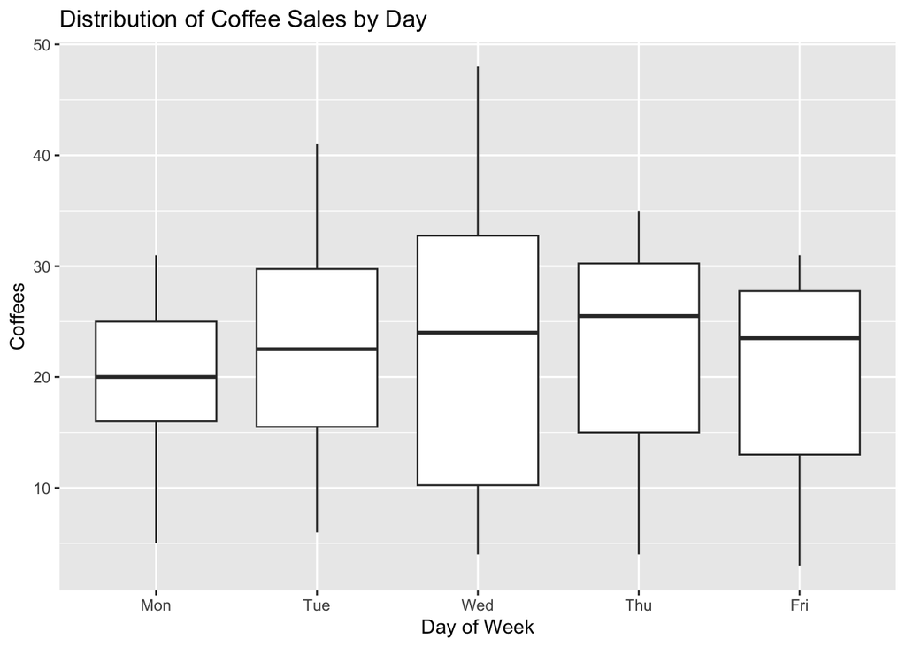

```r
cafedata %>%
  mutate(`Day of Week` = factor(`Day of Week`, levels = c("Sun", "Mon", "Tue", "Wed", "Thu", "Fri", "Sat"))) %>%
  ggplot() +
  geom_boxplot(aes(x = `Day of Week`, y = `Coffees`)) +
  labs(title = "Distribution of Coffee Sales by Day")
```